# Strategien zur Entwicklung von neuen Auswertungen

Peter von Rohr

12/10/2020

## Ausgangslage

Die produktiven Versionen der Programme (inklusive Inputs) der Auswertungen für die Zuchtwertschätzungen (ZWS) sind unter /qualstorzws01/data_zws abgelegt. Für die Milchvieh-ZWS gibt es für jede Merkmalsgruppe ein separates Unterverzeichnis. Die ZWS für die Fleischmerkmale für VMS befinden sich alle unter /qualstorzws01/data_zws/vms. Für die Kleinwiederkäuer (KWK) befinden sich die ZWS unter /qualstorzws01/data_zws/{milchschafe,ziegen}. Die ZWS für Jersey ist unter /qualstorzws01/data_zws/jersey zu finden.

Die Unterverzeichnisse der Auswertungen sind mit Git versioniert. Das heisst in jedem Unterverzeichnis von /qualstorzws01/data_zws befindet sich unter .git ein lokales Repository der versionierten Daten. Am Beispiel der Auswertung für FBK ist das lokale Git-Repository in /qualstorzws01/data_zws/fbk/.git zu finden.

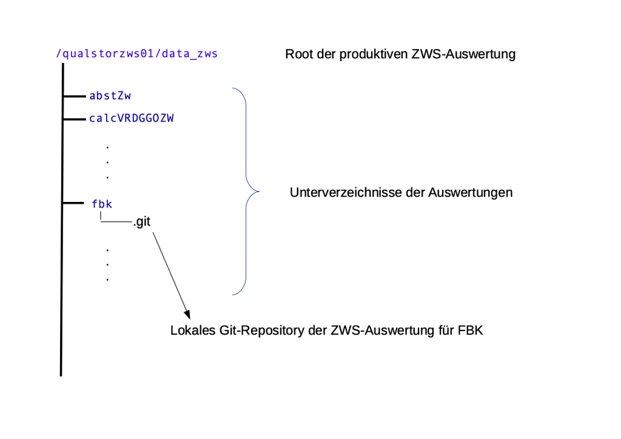

Eine wichtige Eigenschaft der Programm für die produktive Auswertung ist, dass sie vor deren Einsatz in einer Routine-Auswertung getestet sind und dass sie in einer definierten Version vorliegen. Allfällige Änderungen oder Weiterentwicklungen müssen vor deren Einführung zuerst getestet werden. Nach einem erfolgreichen Test können die getesteten Änderungen in die produktive Auswertungen installiert werden. Zeitlich sollte dies vor einer Routine-Auswertung passieren. Mögliche Strategien, wie Anpassungen oder Weiterentwicklungen organisiert werden können wird in den nachfolgenden Abschnitten beschrieben.